# Test a Perceptual Phenomenon

### Analyzing the Stroop Effect

Perform the analysis in the space below. Remember to follow [the instructions](https://docs.google.com/document/d/1-OkpZLjG_kX9J6LIQ5IltsqMzVWjh36QpnP2RYpVdPU/pub?embedded=True) and review the [project rubric](https://review.udacity.com/#!/rubrics/71/view) before submitting. Once you've completed the analysis and write up, download this file as a PDF or HTML file and submit in the next section.

Before answering the questions below I will first import the libraries I need, load the data and take a first look at the data.

```python
#import libraries
import pandas as pd
import numpy as np
import matplotlib.pyplot as plt
import seaborn as sns
%matplotlib inline
sns.set_style('darkgrid')
from scipy.stats import t
import math
```

```python
#load the data
df = pd.read_csv('stroopdata.csv')
df.shape
```

```
(24, 2)
```

A small dataset of 24 rows and 2 columns. With such a small dataset I can easely scan visually for null values and duplicates but that is no fun.

```python
df.info()
```

```
<class 'pandas.core.frame.DataFrame'>
RangeIndex: 24 entries, 0 to 23
Data columns (total 2 columns):
Congruent      24 non-null float64
Incongruent    24 non-null float64
dtypes: float64(2)
memory usage: 464.0 bytes
```

We have two columns with the names 'Congruent' and 'Incongruent' the data in both columns are of type float. Important is that for both columns there are 24 non-null values which is equal to the total number of rows. Therefore there are no null values in this dataset.

```python
df.nunique()
```

```
Congruent      24
Incongruent    24
dtype: int64
```

For both columns we have 24 unique values which is equal to the total number of rows therefore I have no duplicate rows. Now I am ready to move on to the points below.

(1) What is the independent variable? What is the dependent variable?

**Dependent variabele** is the congruency of the words where congruent means that the color of the letters of the word corresponds with the meaning of the word. incongruent means the colors do not match the meaning of the word. For example Green and Red are congruent. Incongruent examples are Red and Blue.

**Independent variabele** is the time to complete the task.

(2) What is an appropriate set of hypotheses for this task? What kind of statistical test do you expect to perform? Justify your choices.

The null hypothesis is that there is no difference between the execution time for reading aloud congruent and incongruent words.

$H_0: \mu_i - \mu_c = 0$

Where $\mu_i$ is the mean response time for the incongruent words and $\mu_c$ is the mean response time for the congruent words.

The alternative hypothesis is that it takes longer to read aloud incongruent words.

$H_1: \mu_i - \mu_c > 0$

I will be using a one-tailed t-test for the following reasons

- This dataset has a small sample size, less than 30
- we don't know the population mean nor the standard deviations
- we have made no assumptions about the normality of the population
- we have dependent samples as the experiment is conducted in such a manner that each participant is measured under congruent and incongruent conditions.

(3) Report some descriptive statistics regarding this dataset. Include at least one measure of central tendency and at least one measure of variability. The name of the data file is 'stroopdata.csv'.

```python
# descriptive stats
df['Difference'] = df['Incongruent'] - df['Congruent']
df.describe()
```

|  | Congruent | Incongruent | Difference |
| --- | --- | --- | --- |
| count | 24.000000 | 24.000000 | 24.000000 |
| mean | 14.051125 | 22.015917 | 7.964792 |
| std | 3.559358 | 4.797057 | 4.864827 |
| min | 8.630000 | 15.687000 | 1.950000 |
| 25% | 11.895250 | 18.716750 | 3.645500 |
| 50% | 14.356500 | 21.017500 | 7.666500 |
| 75% | 16.200750 | 24.051500 | 10.258500 |
| max | 22.328000 | 35.255000 | 21.919000 |

The mean of the difference is 7.96 and the median of the difference is 7.67 seconds. The standard deviation of the difference is 4.86 seconds.

(4) Provide one or two visualizations that show the distribution of the sample data. Write one or two sentences noting what you observe about the plot or plots.

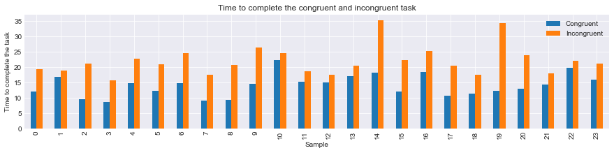

```python
# First lets look at all the data, it is a small dataset after all
plot_title = 'Time to complete the congruent and incongruent task'
plot = df[['Congruent', 'Incongruent']].plot(kind='bar', figsize=(15, 3), title=plot_title)
plot.set_ylabel('Time to complete the task')
plot.set_xlabel('Sample')
```

In the plot above we see that the time to complete the congruent and incongruent task varies from individual to individual. The difference varies also but is always positive, no-one finished the incongruent task faster than the congruent task.

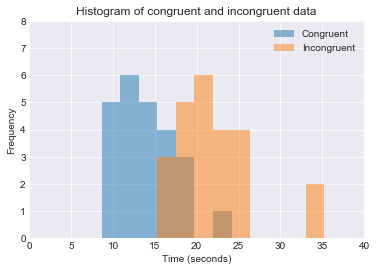

```python
title = 'Histogram of congruent and incongruent data'
plot = df[['Congruent', 'Incongruent']].plot(title=title, kind='hist', alpha=0.5, bins=12)
xLabel = plt.xlabel('Time (seconds)')
window = plt.axis([0,40,0,8])
```

With such a small data set you can not expect a perfect bell curve. We see that de distribution looks kind of normalish with some outliers to the right. Also note that there is a little overlap between the two distributions but not much.

Lets try a boxplot.

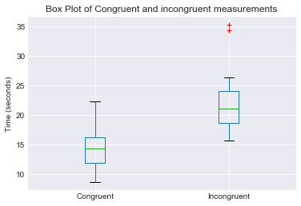

```python
title = 'Box Plot of Congruent and incongruent measurements'
df[['Congruent', 'Incongruent']].plot(title=title, kind='box', sym='r+')
ylabel = plt.ylabel('Time (seconds)')
```

Again we see little overlap between the distibutions. The 25% mark (the bottom of the actual box) of the incongruent data is above the 75% mark (the top of the actual box). A first indication that our null hypothesis is in trouble.

(5) Now, perform the statistical test and report the results. What is the confidence level and your critical statistic value? Do you reject the null hypothesis or fail to reject it? Come to a conclusion in terms of the experiment task. Did the results match up with your expectations?

```python
#The number of samples we found earlier
samples = 24
#Our desired confidence level is 95%
confidence = 0.95
```

```python
#Calculate the degrees of freedom
dof = samples - 1
#Calculate the t-critical value
t_critical = t.ppf(confidence, dof)
print('The t-critical value is ' + str(t_critical))
```

```
The t-critical value is 1.71387152775
```

```python
#calculate the difference of the means
dif_means = df['Incongruent'].mean() - df['Congruent'].mean()
print('The difference of the means is ' + str(dif_means))
```

```
The difference of the means is 7.964791666666665
```

```python
# Calculate the standard deviation of the differences
dif_std = df['Difference'].std(axis=0)
print('The standard deviation of the differences is ' + str(dif_std))
```

```
The standard deviation of the differences is 4.864826910359056
```

```python
#Calculate the t-statistic
t_statistic = dif_means / (dif_std / math.sqrt(samples))
print('The t-statistic is ' + str(t_statistic))
```

```
The t-statistic is 8.020706944109955
```

The value of the t-statistic (8.02) is greater than the t-critical value (1.71) so we can reject the nullhypothesis. It does take longer to perform the incongruent task.